# Poly_PCA

## | Polynomial Regression & PCA |

In this notebook, we will use the same dataset and data preprocessing pipeline as in the Linear Regression notebook. Unlike the previous episode, we will not go through all regression steps (such as coefficient interpretation), and will instead focus on two main aspects:

- **Polynomial Regression**: expanding the feature space through second-degree polynomial terms (including interactions and squared variables), fitting the model, and evaluating its performance.
- **Dimensionality Reduction via PCA**: compressing the high-dimensional polynomial space using Principal Component Analysis, refitting the model on the reduced dataset, and comparing the performance. The goal is to achieve a similar level of accuracy while significantly lowering dimensionality.

```python
# Importing necessary packages
import pandas as pd
import numpy as np
import matplotlib.pyplot as plt
import seaborn as sns
from sklearn.datasets import fetch_california_housing
```

### Preliminary steps

The initial code will be way more compact than the one of the first episode.

```python
# Load dataset
housing = fetch_california_housing()
df = pd.DataFrame(housing.data, columns=housing.feature_names)
df['MedHouseVal'] = housing.target


features_to_check = ['AveRooms', 'AveBedrms', 'AveOccup']
quantile_bounds = df[features_to_check].quantile([0.01, 0.99])

# Create a mask for rows *not* being outliers in any feature
non_outlier_mask = ~df[features_to_check].apply(
    lambda col: (col < quantile_bounds.loc[0.01, col.name]) | (col > quantile_bounds.loc[0.99, col.name])
).any(axis=1)

df_clean = df[non_outlier_mask].copy()

# Log-transform relevant columns
cols_to_log = df_clean.columns.difference(['HouseAge', 'Latitude', 'Longitude', 'MedHouseVal'])
df_ult = df_clean[cols_to_log].apply(np.log).join(df_clean[['HouseAge', 'Latitude', 'Longitude', 'MedHouseVal']])

# Report
print(f"Rows removed due to outliers: {len(df) - len(df_ult)}")
```

```
Rows removed due to outliers: 995
```

```python
# Split into predictors and target variable
## We can overwrite X and y variables for our regression purposes
### This time we will not log-transform y for simplicity - we must make different comparisons
X = df_ult.drop(columns='MedHouseVal')
y = df_ult['MedHouseVal'] # Original scale
# y_log = np.log(y) # Log scale

## Standardize manually and store the parameters
def standardize(df):
    mean = df.mean()
    std = df.std()
    scaled = (df - mean) / std
    return scaled, {'mean': mean, 'std': std}

## Just in case
def inverse_standardize(scaled, params):
    return scaled * params['std'] - params['mean']


# Functions
## Parameters matrix + intercept
def predictors_matrix(X):
    X_b = np.c_[np.ones((X.shape[0], 1)), X] # Bias term + predictors
    return X_b

## Normal Equation - closed form
def normal_equation(X, y):
    X_b = predictors_matrix(X)
    beta = np.linalg.pinv(X_b.T @ X_b) @ X_b.T @ y # We use 'pinv' instead of 'inv' to avoid calculation issues in case of singular matrix
    return beta

## Prediction
def predict(X, beta):
    X_b = predictors_matrix(X)
    y_hat = X_b @ beta # Multiply the predictors by their coefficient
    return y_hat
```

```python
# Fuction to evaluate the model with the most common metrics
def evaluate_model(y_true, y_pred, label="Test Set"):

    mse = np.mean((y_true - y_pred) ** 2)
    rmse = np.sqrt(mse)
    ss_res = np.sum((y_true - y_pred) ** 2)
    ss_tot = np.sum((y_true - np.mean(y_true)) ** 2)
    r2 = 1 - ss_res / ss_tot

    print(f"--- |Evaluation Results| — {label}")
    print("────────────────────────────────────")
    print(f"· MSE : {mse:,.4f}")
    print(f"· RMSE: {rmse:,.4f}")
    print(f"· R²  : {r2:.4f}")
    print("────────────────────────────────────\n")
```

## Creating Polynomial terms

```python
import itertools

def polynomial_features(X, degree=2):
    """
    Generate polynomial features up to a given degree with human-readable names.
    - x * x becomes x_2
    - x * y becomes x_y

    Args:
    - X (pd.DataFrame): Input feature matrix.
    - degree (int): Maximum degree of polynomial expansion.

    Returns:
    - pd.DataFrame: Expanded feature matrix with named polynomial terms.
    """

    X_poly = X.copy()
    feature_names = X.columns

    for d in range(2, degree + 1):
        for comb in itertools.combinations_with_replacement(feature_names, d):
            # Count each variable in the combination
            counts = {feat: comb.count(feat) for feat in set(comb)}

            if len(counts) == 1:
                # Power term, e.g. x^2 → x_2
                feat = list(counts.keys())[0]
                new_name = f"{feat}_{d}"
            else:
                # Interaction term, sorted to keep consistent naming
                sorted_feats = sorted(comb)
                new_name = "_".join(sorted_feats)

            # Compute the product
            X_poly[new_name] = np.prod([X[feat] for feat in comb], axis=0)

    return X_poly

# Creating polynomial features and then scale them
X_poly = polynomial_features(X, degree=2)
X_scaled, scaling_params_X = standardize(X_poly)
```

```python
# Grouping variables
original_features = X_poly.columns[:len(X.columns)]
squared_terms = [col for col in X_poly.columns if "_2" in col]
interaction_terms = [col for col in X_poly.columns if "_" in col[1:] and col not in squared_terms]
print(f"Original features: {len(original_features)}\nSquared terms: {len(squared_terms)}\nInteraction terms: {len(interaction_terms)}\nTOTAL: {len(X_poly.columns)} variables")
```

```
Original features: 8
Squared terms: 8
Interaction terms: 28
TOTAL: 44 variables
```

```python
# Displaying all the features, in an elegant way
def print_in_columns(feature_list, n_cols=4):
    for i, feature in enumerate(feature_list):
        print(f"{i+1}) {feature:<40}", end="")
        if (i + 1) % n_cols == 0:
            print()  # New line after every n_cols features

## Printing features by categories
print("***Original Features***\n")
print_in_columns([feature for feature in X_poly.columns if feature in original_features])

print("\n***Squared Terms***\n")
print_in_columns([feature for feature in X_poly.columns if feature in squared_terms])

print("\n***Interaction Terms***\n")
print_in_columns([feature for feature in X_poly.columns if feature in interaction_terms])
```

```
***Original Features***

1) AveBedrms                               2) AveOccup                                3) AveRooms                                4) MedInc
5) Population                              6) HouseAge                                7) Latitude                                8) Longitude

***Squared Terms***

1) AveBedrms_2                             2) AveOccup_2                              3) AveRooms_2                              4) MedInc_2
5) Population_2                            6) HouseAge_2                              7) Latitude_2                              8) Longitude_2

***Interaction Terms***

1) AveBedrms_AveOccup                      2) AveBedrms_AveRooms                      3) AveBedrms_MedInc                        4) AveBedrms_Population
5) AveBedrms_HouseAge                      6) AveBedrms_Latitude                      7) AveBedrms_Longitude                     8) AveOccup_AveRooms
9) AveOccup_MedInc                         10) AveOccup_Population                     11) AveOccup_HouseAge                       12) AveOccup_Latitude
13) AveOccup_Longitude                      14) AveRooms_MedInc                         15) AveRooms_Population                     16) AveRooms_HouseAge
17) AveRooms_Latitude                       18) AveRooms_Longitude                      19) MedInc_Population                       20) HouseAge_MedInc
21) Latitude_MedInc                         22) Longitude_MedInc                        23) HouseAge_Population                     24) Latitude_Population
25) Longitude_Population                    26) HouseAge_Latitude                       27) HouseAge_Longitude                      28) Latitude_Longitude
```

## Regression

```python
# Set a random seed for reproducibility
np.random.seed(42)

# Shuffle the indices of the dataset
indices = np.random.permutation(len(X_scaled))

# Determine the train size (80% of the data)
train_size = int(0.8 * len(X_scaled))

# Split the indices into training and test sets
train_indices = indices[:train_size]
test_indices = indices[train_size:]

X_train, X_test = X_scaled.iloc[train_indices], X_scaled.iloc[test_indices]
y_train, y_test = y.iloc[train_indices], y.iloc[test_indices]
```

```python
# Fit the model
beta = normal_equation(X_train.values, y_train.values)

y_pred_test = predict(X_test.values, beta)
y_pred_train = predict(X_train.values, beta)

# Evaluate the model
evaluate_model(y_train, y_pred_train, label='Train set')
evaluate_model(y_test, y_pred_test, label='Test set')
```

```
--- |Evaluation Results| — Train set
────────────────────────────────────
· MSE : 0.3250
· RMSE: 0.5701
· R²  : 0.7537
────────────────────────────────────

--- |Evaluation Results| — Test set
────────────────────────────────────
· MSE : 0.3389
· RMSE: 0.5821
· R²  : 0.7469
────────────────────────────────────
```

The difference between train and test set in terms of error metrics is low. The model is not overfitting.

## PCA

Now it is time to reduce the dimensionality of our problem through **Principal Component Analysis**.

The aim of this tool is to project high-dimensional data onto a lower-dimensional space in such a way that the maximum variance in the data is preserved. In simpler terms, PCA finds new axes — called *principal components* — which are linear combinations of the original features and ordered by how much variance they capture.

**Note**: PCA is an Unsupervised Learning technique, i.e. it doesn't "know" the target variable **y**, but rather it acts exclusively on the structure of input data, without considering any predictive power.

### Correlation matrix

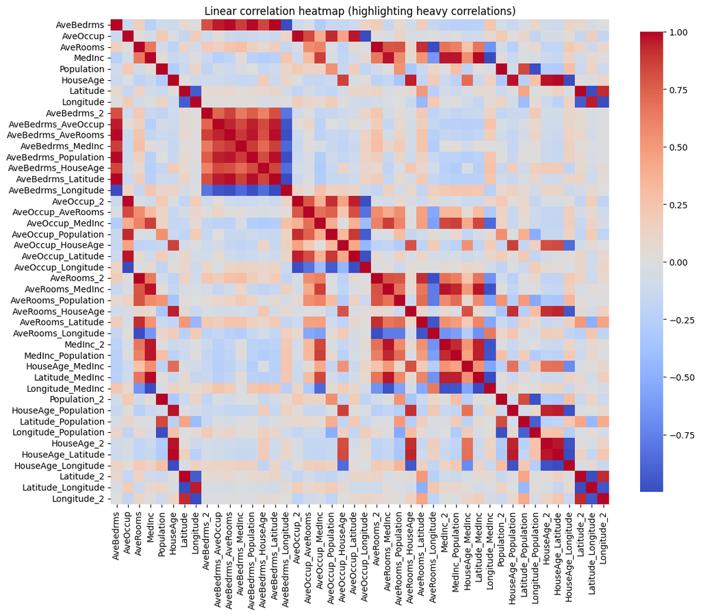

```
Highly correlated feature pairs (|correlation| >= 0.95):

FEATURE 1                FEATURE 2                      CORRELATION

Longitude            -   Longitude_2                    rho = -1.000
AveBedrms            -   AveBedrms_Longitude            rho = -1.000
Latitude             -   Latitude_2                     rho = 1.000
HouseAge             -   HouseAge_Longitude             rho = -0.999
MedInc               -   Longitude_MedInc               rho = -0.999
AveBedrms_Latitude   -   AveBedrms_Longitude            rho = -0.998
AveOccup             -   AveOccup_Longitude             rho = -0.997
AveBedrms            -   AveBedrms_Latitude             rho = 0.997
Latitude             -   Latitude_Longitude             rho = -0.997
Latitude_2           -   Latitude_Longitude             rho = -0.996
AveRooms             -   AveRooms_2                     rho = 0.995
HouseAge_Latitude    -   HouseAge_Longitude             rho = -0.995
Population           -   Population_2                   rho = 0.993
Latitude_MedInc      -   Longitude_MedInc               rho = -0.993
AveRooms             -   AveRooms_Longitude             rho = -0.992
HouseAge             -   HouseAge_Latitude              rho = 0.990
AveOccup             -   AveOccup_2                     rho = 0.989
AveRooms_2           -   AveRooms_Longitude             rho = -0.987
AveBedrms            -   AveBedrms_Population           rho = 0.987
MedInc               -   Latitude_MedInc                rho = 0.986
AveBedrms_Population -   AveBedrms_Longitude            rho = -0.986
AveBedrms            -   AveBedrms_AveRooms             rho = 0.985
AveBedrms_AveRooms   -   AveBedrms_Longitude            rho = -0.985
Population           -   Longitude_Population           rho = -0.985
AveOccup_2           -   AveOccup_Longitude             rho = -0.984
AveBedrms_AveRooms   -   AveBedrms_Latitude             rho = 0.984
AveBedrms_Population -   AveBedrms_Latitude             rho = 0.982
AveOccup_Latitude    -   AveOccup_Longitude             rho = -0.979
Population_2         -   Longitude_Population           rho = -0.978
HouseAge             -   HouseAge_Population            rho = 0.974
HouseAge_2           -   HouseAge_Longitude             rho = -0.974
HouseAge             -   HouseAge_2                     rho = 0.973
HouseAge_Population  -   HouseAge_Longitude             rho = -0.973
MedInc               -   AveRooms_MedInc                rho = 0.971
AveRooms_MedInc      -   MedInc_2                       rho = 0.971
AveRooms_MedInc      -   Longitude_MedInc               rho = -0.970
AveBedrms_AveRooms   -   AveBedrms_Population           rho = 0.968
HouseAge_2           -   HouseAge_Latitude              rho = 0.968
AveOccup             -   AveOccup_Latitude              rho = 0.963
MedInc               -   MedInc_2                       rho = 0.963
MedInc               -   MedInc_Population              rho = 0.963
AveRooms_MedInc      -   Latitude_MedInc                rho = 0.962
MedInc_2             -   Longitude_MedInc               rho = -0.962
MedInc_Population    -   Longitude_MedInc               rho = -0.961
HouseAge_Population  -   HouseAge_Latitude              rho = 0.960
AveBedrms            -   AveBedrms_AveOccup             rho = 0.960
AveBedrms_AveOccup   -   AveBedrms_Longitude            rho = -0.960
AveRooms_Latitude    -   AveRooms_Longitude             rho = -0.957
AveBedrms_AveOccup   -   AveBedrms_Latitude             rho = 0.957
Latitude_Longitude   -   Longitude_2                    rho = -0.956
Longitude            -   Latitude_Longitude             rho = 0.955
AveBedrms_AveOccup   -   AveBedrms_Population           rho = 0.952
```

```python
# Collinearities

## Calculate correlation matrix of the polynomial set of features
corr_matrix = X_poly.corr()
threshold = 0.95 # threshold for heavy correlation

## Create a boolean mask where |correlation| > threshold
heavy_corr_mask = (np.abs(corr_matrix) > threshold) & (np.abs(corr_matrix) <= 1)

## Heatmap
plt.figure(figsize=(12, 10))
sns.heatmap(corr_matrix,
            cmap='coolwarm',
            fmt='',
            center=0,
            cbar_kws={"shrink": threshold})
plt.title("Linear correlation heatmap (highlighting heavy correlations)")
plt.tight_layout()
plt.show()

heavy_corr_pairs = []
for i in range(corr_matrix.shape[0]):
    for j in range(i+1, corr_matrix.shape[1]):
        if abs(corr_matrix.iloc[i, j]) >= threshold:
            heavy_corr_pairs.append((corr_matrix.index[i], corr_matrix.columns[j], corr_matrix.iloc[i, j]))

heavy_corr_pairs = sorted(heavy_corr_pairs, key=lambda x: -abs(x[2])) # Sorting

print(f"Highly correlated feature pairs (|correlation| >= {threshold}):\n")
print(f"{"FEATURE 1":<20}     {"FEATURE 2":<30} {"CORRELATION":<3}\n")
for feature1, feature2, corr_value in heavy_corr_pairs:
    print(f"{feature1:<20} - {' ':>2}{feature2:<30} rho = {corr_value:<2.3f}")
```

### Reducing dimensionality

```python
# PCA function - full manual mode

def principal_component_analysis(X_scaled, selected_columns, k=None, variance_threshold=0.95, verbose=True):
    """
    Performs manual PCA on a selected subset of features.

    Args:
        X_scaled (pd.DataFrame): The df of full scaled feature matrix centered around 0, with standard deviation equal to 1.
        selected_columns (list): Indices of columns to perform PCA on.
        k (int, optional): The number of principal components to keep. If None, select minimum number to reach variance_threshold.
        variance_threshold (float, optional): Minimum cumulative explained variance to reach if k is None. Default is 0.95.
        verbose (bool, optional): If True, prints info messages. Default is True.

    Returns:
        X_pca (np.ndarray): The data projected onto the top k principal components (samples x k).
        pca_components (np.ndarray): The top k principal components (eigenvectors) (p x k).
        explained_variance_ratio (np.ndarray): Variance explained by each of the top k components.
        cumulative_explained_variance (np.ndarray): Cumulative variance explained.
        original_subset_mean (np.ndarray): Mean of the selected features (needed for potential inverse transform).
    """
    if verbose:
        print(f"Selected feature indices for PCA:\n{selected_columns} --- ({len(selected_columns)} variables)\n")

    # 1. Select the Subset of Features
    X_subset = X_scaled[selected_columns]
    p = X_subset.shape[1] # Number of features in the subset

    # 2. Calculate the Covariance Matrix
    m = X_scaled.shape[0] # Number of samples
    cov_matrix = np.cov(X_subset, rowvar=False, ddof=1) # Sample covariance

    # 3. Eigenvalue Decomposition
    eigenvalues, eigenvectors = np.linalg.eigh(cov_matrix)

    # 4. Sort Eigenvalues and Eigenvectors
    sorted_indices = np.argsort(eigenvalues)[::-1]
    sorted_eigenvalues = eigenvalues[sorted_indices]
    sorted_eigenvectors = eigenvectors[:, sorted_indices]

    # 5. Calculate Explained Variance
    total_variance = np.sum(sorted_eigenvalues)
    explained_variance_ratio_full = sorted_eigenvalues / total_variance
    cumulative_explained_variance_full = np.cumsum(explained_variance_ratio_full)

    # 6. Select number of Components
    if k is None:
        # Automatic selection based on variance threshold
        k = np.searchsorted(cumulative_explained_variance_full, variance_threshold) + 1
        if verbose:
            print(f"No k provided. Selected {k} components to reach at least {variance_threshold*100:.1f}% explained variance.")
    else:
        if k > p:
            raise ValueError(f"k ({k}) cannot be greater than the number of selected features ({p})")
        if verbose:
            print(f"Number of components to keep (k): {k}")

    pca_components = sorted_eigenvectors[:, :k]
    explained_variance_ratio = explained_variance_ratio_full[:k]
    cumulative_explained_variance = cumulative_explained_variance_full[:k]

    if verbose:
        print(f"Explained variance ratio (top {k}): {explained_variance_ratio.round(4)}")
        print(f"Cumulative explained variance (top {k}): {cumulative_explained_variance.round(4)}")
        print("-"*50, "\n")

    # 7. Project the Data
    X_pca = X_subset @ pca_components

    # 8. Save the mean for potential inverse-transform
    original_subset_mean = X_subset.mean(axis=0).to_numpy()

    # return X_pca, pca_components, explained_variance_ratio, cumulative_explained_variance, original_subset_mean
    return X_pca, pca_components, original_subset_mean
```

```python
# Applying PCA step-by-step

## Define the dictionary with PCA groups and filters
pca_groups = {
    "Bedrooms": lambda col: "AveBedrms" in col,
    "Occupants": lambda col: "AveOccup" in col,
    "Rooms": lambda col: "AveRooms" in col,
    "Population": lambda col: "Population" in col,
    "HouseAge": lambda col: "HouseAge" in col,
    "Location": lambda col: "Latitude" in col or "Longitude" in col,
    "Income": lambda col: col in ["MedInc", "MedInc_2"]
}

## Track already used columns to avoid overlaps (this is thought for interaction terms)
used_columns = set()

## Lists to tore final principal components
pcs_train = []
pcs_test = []

## Renaming function for interpretability of PCs
def rename_pc(pc: pd.DataFrame, name: str):
    pc.columns = [f"PC_{name}_{i+1}" for i in range(pc.shape[1])]
    return pc

## Apply PCA to each group
for name, condition in pca_groups.items():
    group_cols = [col for col in X_scaled.columns if condition(col) and col not in used_columns]
    used_columns.update(group_cols)

    ## Train PCA ---> we do not do it on the whole dataset so that we do not leak information
    k_value = 3 if name == "Location" else None # k is forced to 3 for location because I want to keep the most possible variance
    X_pca_train, components, mean_vec = principal_component_analysis(X_train, group_cols, k=k_value)

    ## Apply to test set
    X_subset_test = X_test[group_cols]
    X_pca_test = (X_subset_test - mean_vec) @ components

    ### Convert to DataFrames
    pc_train_df = pd.DataFrame(X_pca_train, index=X_train.index)
    pc_test_df = pd.DataFrame(X_pca_test, index=X_test.index)

    ### Rename columns
    pc_train_df = rename_pc(pc_train_df, name)
    pc_test_df = rename_pc(pc_test_df, name)

    ### Store
    pcs_train.append(pc_train_df)
    pcs_test.append(pc_test_df)

### Final DataFrames made of PCs ###
X_train_pca = pd.concat(pcs_train, axis=1)
X_test_pca = pd.concat(pcs_test, axis=1)
```

```
Selected feature indices for PCA:
['AveBedrms', 'AveBedrms_2', 'AveBedrms_AveOccup', 'AveBedrms_AveRooms', 'AveBedrms_MedInc', 'AveBedrms_Population', 'AveBedrms_HouseAge', 'AveBedrms_Latitude', 'AveBedrms_Longitude'] --- (9 variables)

No k provided. Selected 3 components to reach at least 95.0% explained variance.
Explained variance ratio (top 3): [0.8956 0.0464 0.0324]
Cumulative explained variance (top 3): [0.8956 0.942  0.9744]
--------------------------------------------------

Selected feature indices for PCA:
['AveOccup', 'AveOccup_2', 'AveOccup_AveRooms', 'AveOccup_MedInc', 'AveOccup_Population', 'AveOccup_HouseAge', 'AveOccup_Latitude', 'AveOccup_Longitude'] --- (8 variables)

No k provided. Selected 3 components to reach at least 95.0% explained variance.
Explained variance ratio (top 3): [0.7421 0.139  0.0798]
Cumulative explained variance (top 3): [0.7421 0.881  0.9609]
--------------------------------------------------

Selected feature indices for PCA:
['AveRooms', 'AveRooms_2', 'AveRooms_MedInc', 'AveRooms_Population', 'AveRooms_HouseAge', 'AveRooms_Latitude', 'AveRooms_Longitude'] --- (7 variables)

No k provided. Selected 4 components to reach at least 95.0% explained variance.
Explained variance ratio (top 4): [0.7429 0.1498 0.0541 0.0408]
Cumulative explained variance (top 4): [0.7429 0.8927 0.9468 0.9876]
--------------------------------------------------

Selected feature indices for PCA:
['Population', 'MedInc_Population', 'Population_2', 'HouseAge_Population', 'Latitude_Population', 'Longitude_Population'] --- (6 variables)

No k provided. Selected 3 components to reach at least 95.0% explained variance.
Explained variance ratio (top 3): [0.6462 0.1817 0.1341]
Cumulative explained variance (top 3): [0.6462 0.8279 0.962 ]
--------------------------------------------------

Selected feature indices for PCA:
['HouseAge', 'HouseAge_MedInc', 'HouseAge_2', 'HouseAge_Latitude', 'HouseAge_Longitude'] --- (5 variables)

No k provided. Selected 2 components to reach at least 95.0% explained variance.
Explained variance ratio (top 2): [0.8998 0.0902]
Cumulative explained variance (top 2): [0.8998 0.99  ]
--------------------------------------------------

Selected feature indices for PCA:
['Latitude', 'Longitude', 'Latitude_MedInc', 'Longitude_MedInc', 'Latitude_2', 'Latitude_Longitude', 'Longitude_2'] --- (7 variables)

Number of components to keep (k): 3
Explained variance ratio (top 3): [0.694  0.2853 0.0206]
Cumulative explained variance (top 3): [0.694  0.9792 0.9998]
--------------------------------------------------

Selected feature indices for PCA:
['MedInc', 'MedInc_2'] --- (2 variables)

No k provided. Selected 1 components to reach at least 95.0% explained variance.
Explained variance ratio (top 1): [0.982]
Cumulative explained variance (top 1): [0.982]
--------------------------------------------------
```

```python
# Check dimensionality and column names
X_train_pca
```

|  | PC_Bedrooms_1 | PC_Bedrooms_2 | PC_Bedrooms_3 | PC_Occupants_1 | PC_Occupants_2 | PC_Occupants_3 | PC_Rooms_1 | PC_Rooms_2 | PC_Rooms_3 | PC_Rooms_4 | PC_Population_1 | PC_Population_2 | PC_Population_3 | PC_HouseAge_1 | PC_HouseAge_2 | PC_Location_1 | PC_Location_2 | PC_Location_3 | PC_Income_1 |
| --- | --- | --- | --- | --- | --- | --- | --- | --- | --- | --- | --- | --- | --- | --- | --- | --- | --- | --- | --- |
| 12110 | 2.754206 | -0.405874 | 0.165059 | -0.258855 | -0.025462 | -0.568359 | -0.499991 | 0.499219 | -0.314631 | -0.675245 | -1.083236 | -0.156890 | 0.576389 | 1.179265 | -0.174057 | 2.100425 | 0.784131 | -0.301394 | -0.859027 |
| 1182 | 0.722881 | -0.222423 | 0.221657 | 0.256555 | -0.239287 | -0.625993 | -1.262614 | 0.533396 | -0.928068 | 0.000281 | -0.549573 | 0.220221 | 0.802422 | 1.466458 | -0.122992 | -3.204470 | 0.525309 | -0.861144 | -0.593927 |
| 3845 | -1.732559 | 0.184397 | -0.033049 | 0.387499 | 0.352713 | -0.357549 | 3.432150 | 0.546804 | 0.655872 | 0.027534 | -1.329126 | -0.319097 | 0.139809 | 0.474663 | -0.060267 | 1.440994 | 0.385672 | 0.156560 | -0.507995 |
| 5765 | -0.548214 | -0.056738 | 0.101586 | 0.046547 | 0.125055 | -1.183405 | 3.362862 | 1.227569 | 0.479681 | -0.205456 | -2.734475 | -0.061488 | 0.960521 | 2.093213 | -0.175982 | 1.553128 | 0.899289 | 0.121379 | -0.984449 |
| 17445 | -2.165118 | 0.267817 | -0.177994 | 0.722545 | -1.375617 | -0.995291 | -0.618167 | 1.838443 | -0.112622 | 0.634635 | 0.575913 | 1.899647 | 0.923797 | 3.863621 | -0.046477 | 0.121774 | -0.561786 | 0.896392 | 0.402134 |
| ... | ... | ... | ... | ... | ... | ... | ... | ... | ... | ... | ... | ... | ... | ... | ... | ... | ... | ... | ... |
| 7779 | -0.609389 | -0.127073 | 0.016010 | -2.369819 | 0.308988 | -0.178495 | 1.729286 | 0.252203 | 0.403032 | -0.293193 | -1.190007 | -0.387936 | -0.033905 | 0.140381 | -0.019694 | 1.780982 | 0.289624 | 0.075010 | -0.408131 |
| 16247 | 2.891578 | -0.889821 | -0.627894 | -0.223319 | 0.927341 | 0.618898 | -0.833386 | -1.552075 | -0.938038 | 0.101730 | 2.314004 | -0.763765 | -0.005025 | -2.381016 | -0.559286 | -2.159118 | 0.842123 | -0.192032 | -0.903175 |
| 6271 | 1.600413 | -0.463284 | -0.134181 | -0.247616 | 0.833890 | -0.753371 | 3.851853 | 0.596691 | 0.429091 | -0.141409 | -1.503984 | -0.784008 | 0.671428 | 0.631923 | -0.435145 | 1.820664 | 1.303738 | 0.036001 | -1.334099 |
| 14123 | -0.117082 | -0.001584 | 0.016891 | 0.494152 | 0.528756 | -1.981994 | 3.399330 | 1.463929 | -0.296815 | -0.086210 | -0.064564 | 0.065184 | 2.225784 | 3.084992 | -0.416808 | 3.034674 | 2.507728 | 0.300753 | -2.293008 |
| 639 | -3.437914 | 0.925561 | 0.093274 | 3.450825 | 0.718017 | 0.610772 | 1.442981 | -1.337996 | -0.015469 | 0.394258 | 1.987740 | -0.815175 | -0.551282 | -3.324996 | -0.152436 | -2.484071 | 0.079042 | 0.330744 | -0.246651 |

15716 rows × 19 columns

We have reduced the original set of 44 polynomial features to 19 principal components, which capture the most significant variance in the data.

In simple terms, we have compressed initial information.

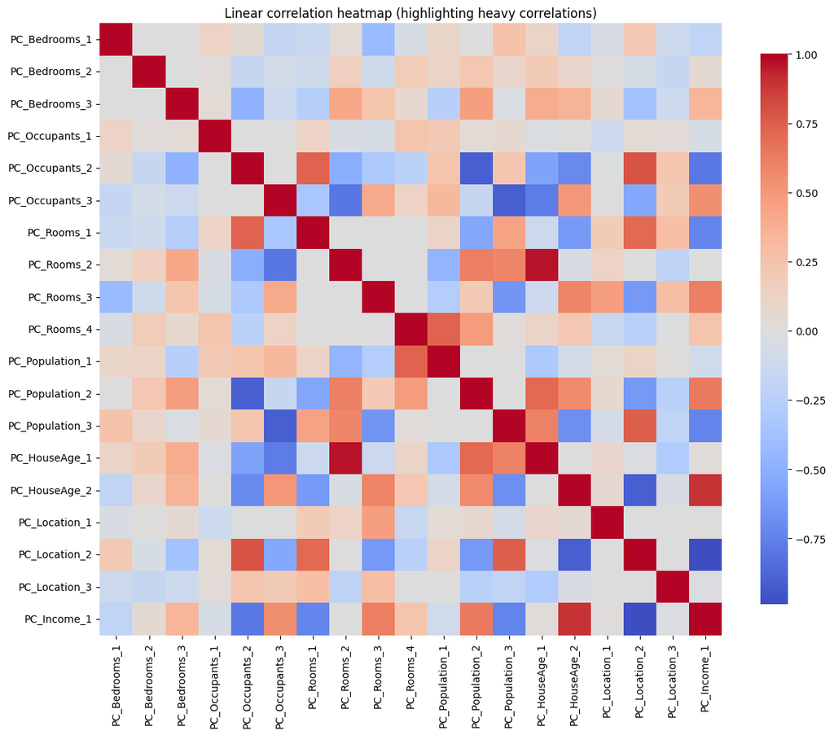

```
Highly correlated feature pairs (|correlation| >= 0.9):

FEATURE 1                FEATURE 2                      CORRELATION

PC_Location_2        -   PC_Income_1                    rho = -0.990
PC_Rooms_2           -   PC_HouseAge_1                  rho = 0.965
PC_HouseAge_2        -   PC_Location_2                  rho = -0.909
PC_Occupants_2       -   PC_Population_2                rho = -0.908
PC_Occupants_3       -   PC_Population_3                rho = -0.905
```

```python
# Let us check again correlations
## Recycling the code from before

## Calculate correlation matrix of the polynomial set of features
corr_matrix = X_train_pca.corr()
threshold = 0.9 # threshold for heavy correlation

## Create a boolean mask where |correlation| > threshold
heavy_corr_mask = (np.abs(corr_matrix) > threshold) & (np.abs(corr_matrix) <= 1)

## Heatmap
plt.figure(figsize=(12, 10))
sns.heatmap(corr_matrix,
            cmap='coolwarm',
            fmt='',
            center=0,
            cbar_kws={"shrink": threshold})
plt.title("Linear correlation heatmap (highlighting heavy correlations)")
plt.tight_layout()
plt.show()

heavy_corr_pairs = []
for i in range(corr_matrix.shape[0]):
    for j in range(i+1, corr_matrix.shape[1]):
        if abs(corr_matrix.iloc[i, j]) >= threshold:
            heavy_corr_pairs.append((corr_matrix.index[i], corr_matrix.columns[j], corr_matrix.iloc[i, j]))

heavy_corr_pairs = sorted(heavy_corr_pairs, key=lambda x: -abs(x[2])) # Sorting

print(f"Highly correlated feature pairs (|correlation| >= {threshold}):\n")
print(f"{"FEATURE 1":<20}     {"FEATURE 2":<30} {"CORRELATION":<3}\n")
for feature1, feature2, corr_value in heavy_corr_pairs:
    print(f"{feature1:<20} - {' ':>2}{feature2:<30} rho = {corr_value:<2.3f}")
```

There is still some correlation because the principal components were derived from interaction terms of features that may appear in multiple components. However, in a typical setting where we use models like Random Forests instead of polynomial features, this issue can be more easily avoided.

### Fitting, evaluating, comparing

```python
# Recall error metrics of the original polynomial regression (44 features)
evaluate_model(y_train, y_pred_train, label='Train set')
evaluate_model(y_test, y_pred_test, label='Test set')
```

```
--- |Evaluation Results| — Train set
────────────────────────────────────
· MSE : 0.3250
· RMSE: 0.5701
· R²  : 0.7537
────────────────────────────────────

--- |Evaluation Results| — Test set
────────────────────────────────────
· MSE : 0.3389
· RMSE: 0.5821
· R²  : 0.7469
────────────────────────────────────
```

```python
# Fit and evaluate the model with 19 principal components
beta_pca = normal_equation(X_train_pca.values, y_train.values)
y_pred_test_pca = predict(X_test_pca.values, beta_pca)
y_pred_train_pca = predict(X_train_pca.values, beta_pca)

# Evaluate the model
evaluate_model(y_train, y_pred_train_pca, label='Train set')
evaluate_model(y_test, y_pred_test_pca, label='Test set')
```

```
--- |Evaluation Results| — Train set
────────────────────────────────────
· MSE : 0.3606
· RMSE: 0.6005
· R²  : 0.7267
────────────────────────────────────

--- |Evaluation Results| — Test set
────────────────────────────────────
· MSE : 0.3709
· RMSE: 0.6090
· R²  : 0.7230
────────────────────────────────────
```

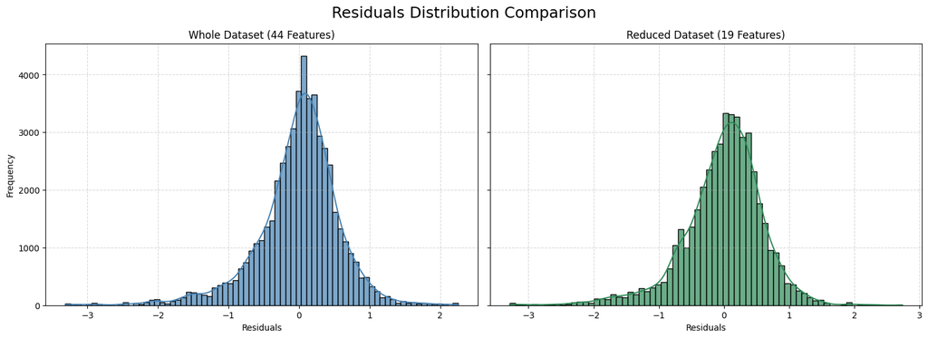

```python
# Residuals analysis
residuals = y_pred_test - y_test
residuals_pca = y_pred_test_pca - y_test

fig, axes = plt.subplots(1, 2, figsize=(15, 5), sharey=True, constrained_layout=True)

sns.histplot(residuals, stat='frequency', color='steelblue', kde=True, ax=axes[0], alpha=0.7, linewidth=1)
axes[0].set_xlabel("Residuals")
axes[0].set_ylabel("Frequency")
axes[0].set_title("Whole Dataset (44 Features)")
axes[0].grid(True, linestyle='--', alpha=0.5)

sns.histplot(residuals_pca, stat='frequency', color='seagreen', kde=True, ax=axes[1], alpha=0.7, linewidth=1)
axes[1].set_xlabel("Residuals")
axes[1].set_title("Reduced Dataset (19 Features)")
axes[1].grid(True, linestyle='--', alpha=0.5)

fig.suptitle("Residuals Distribution Comparison", fontsize=18, y=1.07)

plt.show()
```

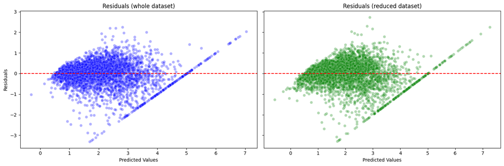

```python
fig, axes = plt.subplots(1, 2, figsize=(15, 5), sharey=True)

sns.scatterplot(ax=axes[0], x=y_pred_test, y=residuals, alpha=0.3, color='blue')
axes[0].axhline(y=0, color='red', linestyle='--', linewidth=1.5, label='Zero Residual')
axes[0].set_title('Residuals (whole dataset)')
axes[0].set_xlabel('Predicted Values')
axes[0].set_ylabel('Residuals')

sns.scatterplot(ax=axes[1], x=y_pred_test_pca, y=residuals_pca, alpha=0.3, color='green')
axes[1].axhline(y=0, color='red', linestyle='--', linewidth=1.5, label='Zero Residual')
axes[1].set_title('Residuals (reduced dataset)')
axes[1].set_xlabel('Predicted Values')

plt.tight_layout()
plt.show()
```

### Conclusion

We successfully reduced the dimensionality of the problem without sacrificing much explanatory power or model performance.

Although performance slightly worsened, the goal of this guide was to show that dimensionality can be reduced without significant loss in predictive capability. In real-world applications, this often results in more stable, interpretable, and computationally efficient models.

In general, PCA is best suited for aggregating highly correlated features into a smaller number of principal components. For example, in financial time series, you may have eight features capturing aspects of volatility and volume that are highly collinear; PCA can reduce them to, say, three orthogonal components that retain most of the original variance.

PCA is not typically applied to polynomial interaction terms, as these are often designed to capture non-linear relationships rather than reduce redundancy. However, this exercise offered a valuable demonstration of how PCA can still be applied in such contexts—especially when dealing with feature-engineered datasets.

```python
### Done!!
```